# Titanic Survivor Case Study

A Comparison of Classification Algorithms

Mike Silva

April 4th, 2015

# Introduction

## Data Used in This Study

The survivor data used in this analyis is found in [Carnegie Mellon University Department of Statitics’s StatLib](http://lib.stat.cmu.edu/S/Harrell/data/descriptions/titanic.html). This dataset describes the survival status of individual passengers on the Titanic. It should be noted that the crew are excluded from this dataset.

The principal source for data about Titanic passengers is the *Encyclopedia Titanica* available online at http://atschool.eduweb.co.uk/phind. The datasets used here were begun by a variety of researchers. One of the original sources is Eaton & Haas (1994) *Titanic: Triumph and Tragedy*, Patrick Stephens Ltd, which includes a passenger list created by many researchers and edited by Michael A. Findlay.

Thomas Cason of UVa has greatly updated and improved the original titanic passenger list. This list does not have the crew but it does contain actual and estimated ages for almost 80% of the passengers. To learn more about how the data was assempled, I would recommend you read http://lib.stat.cmu.edu/S/Harrell/data/descriptions/titanic3info.txt.

In order to pull in the data the follwing commands were executed:

```r
# Download Excel file if not present
if(!file.exists('titanic3.xls')){
  download.file('http://lib.stat.cmu.edu/S/Harrell/data/xls/titanic3.xls', 'titanic3.xls')
}

# Read the data into a data frame
library(plyr) # This will be needed latter but needs to be loaded before dplyr
library(dplyr)
library(XLConnect)

titanic <- loadWorkbook('titanic3.xls') %>%
  readWorksheet(., sheet='titanic3')
```

There are 1309 records in the dataset and 14 variables. The variables in the extracted dataset are pclass, survived, name, sex, age, sibsp, parch, ticket, fare, cabin, embarked, boat, body, home.dest. pclass refers to passenger class (1st, 2nd, 3rd), and is a proxy for socio-economic class. Age is in years and some infants had fractional values. For clarity we will convert the survived variable from a boolean to a categorical.

```r
titanic <- titanic %>%
  mutate(survived = as.factor(ifelse(survived==1,'Yes','No')))
```

If you are unfamiliar with this dataset you can view the whole thing in the Appendix section of this paper.

# Data Processing

We want the models to based on characteristics of the passenger. We will be removing the name of the individual, ticket number, cabin and home/destination variables as they do not have any predictive value. The lifeboat and body identification number will also be dropped because they don’t tell us much about the person. We will also only select the records that have complete information. Some of the variables are closely correlated (i.e. pclass and fare) but I have chosen to leave them in.

```r
study.variables <- c('pclass', 'survived', 'sex', 'age', 'sibsp', 'parch', 'fare', 'embarked')
# Select the study variables and drop all other variables
study.data <- titanic[, study.variables]
# Remove the observations with NA's
study.data <- study.data[complete.cases(study.data),]
```

The study dataset contains 1043 and the 8 variables defined above. The study data was divided into training and testing sets using an 80/20 split. In order to make these results reproducible, a random number seed is defined which will be used throughout this study.

```r
library(caret)
# Set the random number seed
study.seed <- 12345
set.seed(study.seed)
in.train <- createDataPartition(y=study.data$survived, times=1, p=0.80, list=FALSE)
training <- study.data[in.train,]
testing <- study.data[-in.train,]
```

# Baseline Model - Women and Children First

In order to evaluate the accuracy of a model I needed a baseline. We know the people who survived the sinking of the Titanic were those who were able to get a spot on a life boat. One general rule on who get’s a spot is “women and children first.” I will use stictly apply this this rule as the baseline defining a child as a person under 18 years of age:

```r
# Women and Children First rule
survived.rule <- function(age, sex){
  if(sex == 'female' | age < 18){
    return('Yes')
  }
  else{
    return('No')
  }
}
```

I will then apply the baseline model to form predictions:

```r
start <- proc.time()
baseline.predictions <- testing %>%
  select(age, sex) %>%
  apply(., 1, function(x){survived.rule(x[1],x[2])})
baseline.time <- proc.time() - start
```

I will then evaluate the accuracy of this baseline model by comparing the number of times it correctly predicted the outcome relative to the total number of cases:

```r
baseline.confusion.matrix <- testing %>%
  select(survived) %>%
  cbind(., baseline.predictions) %>%
  mutate(truth = as.character(survived)) %>%
  mutate(model = as.character(baseline.predictions)) %>%
  mutate(count=1) %>%
  xtabs(count~model+truth, data=.) %>%
  confusionMatrix(.)

baseline.confusion.matrix
```

```
## Confusion Matrix and Statistics
##
##      truth
## model  No Yes
##   No  100  21
##   Yes  23  64
##
##                Accuracy : 0.7885
##                  95% CI : (0.7266, 0.8419)
##     No Information Rate : 0.5913
##     P-Value [Acc > NIR] : 1.348e-09
##
##                   Kappa : 0.5639
##  Mcnemar's Test P-Value : 0.8802
##
##             Sensitivity : 0.8130
##             Specificity : 0.7529
##          Pos Pred Value : 0.8264
##          Neg Pred Value : 0.7356
##              Prevalence : 0.5913
##          Detection Rate : 0.4808
##    Detection Prevalence : 0.5817
##       Balanced Accuracy : 0.7830
##
##        'Positive' Class : No
##
```

## Reliability of the Baseline Model

The “women and children first” model has an accuracy of 78.85% and a kappa of 56.39%.

# Machine Learning Models

Now that a baseline has been established we will compare it to other machine learning models and observe how it preforms against the baseline.

I will be using R’s caret package to develop eight models. Each model will have 3 repeats of a 10-fold cross validation or 30 results. We will use a common random number seed to ensure that the models get the same data partitions and repeats. We will compare the average accuracy and kappa of these models with the baseline discussed in the previous section. The algorythms were selected in no specific order.

```r
# Set up the 3 repeats and 10-fold cross validation
study.folds <- 10
study.repeats <- 3
study.control <- trainControl(method='repeatedcv', number=study.folds, repeats=study.repeats)
```

## Model 1: Random Forest

```r
set.seed(study.seed)
start <- proc.time()
rf.model <- train(survived~., training, method='rf', trControl=study.control)
rf.prediction <- predict(rf.model, newdata=testing)
rf.confusion.matrix <- confusionMatrix(rf.prediction, testing$survived)
rf.time <- proc.time() - start
rf.confusion.matrix
```

```
## Confusion Matrix and Statistics
##
##           Reference
## Prediction  No Yes
##        No  119  28
##        Yes   4  57
##
##                Accuracy : 0.8462
##                  95% CI : (0.7898, 0.8923)
##     No Information Rate : 0.5913
##     P-Value [Acc > NIR] : 1.596e-15
##
##                   Kappa : 0.6672
##  Mcnemar's Test P-Value : 4.785e-05
##
##             Sensitivity : 0.9675
##             Specificity : 0.6706
##          Pos Pred Value : 0.8095
##          Neg Pred Value : 0.9344
##              Prevalence : 0.5913
##          Detection Rate : 0.5721
##    Detection Prevalence : 0.7067
##       Balanced Accuracy : 0.8190
##
##        'Positive' Class : No
##
```

## Model 2: Learning Vector Quantization

```r
set.seed(study.seed)
start <- proc.time()
lvq.model <- train(survived~., study.data, method='lvq', trControl=study.control)
lvq.prediction <- predict(lvq.model, newdata=testing)
lvq.confusion.matrix <- confusionMatrix(lvq.prediction, testing$survived)
lvq.time <- proc.time() - start
lvq.confusion.matrix
```

```
## Confusion Matrix and Statistics
##
##           Reference
## Prediction  No Yes
##        No  106  58
##        Yes  17  27
##
##                Accuracy : 0.6394
##                  95% CI : (0.5701, 0.7047)
##     No Information Rate : 0.5913
##     P-Value [Acc > NIR] : 0.08949
##
##                   Kappa : 0.1939
##  Mcnemar's Test P-Value : 3.86e-06
##
##             Sensitivity : 0.8618
##             Specificity : 0.3176
##          Pos Pred Value : 0.6463
##          Neg Pred Value : 0.6136
##              Prevalence : 0.5913
##          Detection Rate : 0.5096
##    Detection Prevalence : 0.7885
##       Balanced Accuracy : 0.5897
##
##        'Positive' Class : No
##
```

## Model 3: Support Vector Machine

```r
set.seed(study.seed)
start <- proc.time()
svm.model <- train(survived~., study.data, method='svmRadial', trControl=study.control)
svm.prediction <- predict(svm.model, newdata=testing)
svm.confusion.matrix <- confusionMatrix(svm.prediction, testing$survived)
svm.time <- proc.time() - start
svm.confusion.matrix
```

```
## Confusion Matrix and Statistics
##
##           Reference
## Prediction  No Yes
##        No  117  24
##        Yes   6  61
##
##                Accuracy : 0.8558
##                  95% CI : (0.8005, 0.9005)
##     No Information Rate : 0.5913
##     P-Value [Acc > NIR] : < 2.2e-16
##
##                   Kappa : 0.6915
##  Mcnemar's Test P-Value : 0.001911
##
##             Sensitivity : 0.9512
##             Specificity : 0.7176
##          Pos Pred Value : 0.8298
##          Neg Pred Value : 0.9104
##              Prevalence : 0.5913
##          Detection Rate : 0.5625
##    Detection Prevalence : 0.6779
##       Balanced Accuracy : 0.8344
##
##        'Positive' Class : No
##
```

## Model 4: Gradient Boosted Machine

```r
set.seed(study.seed)
start <- proc.time()
gbm.model <- train(survived~., study.data, method='gbm', trControl=study.control, verbose=FALSE)
gbm.prediction <- predict(gbm.model, newdata=testing)
gbm.confusion.matrix <- confusionMatrix(gbm.prediction, testing$survived)
gbm.time <- proc.time() - start
gbm.confusion.matrix
```

```
## Confusion Matrix and Statistics
##
##           Reference
## Prediction  No Yes
##        No  116  23
##        Yes   7  62
##
##                Accuracy : 0.8558
##                  95% CI : (0.8005, 0.9005)
##     No Information Rate : 0.5913
##     P-Value [Acc > NIR] : < 2e-16
##
##                   Kappa : 0.6926
##  Mcnemar's Test P-Value : 0.00617
##
##             Sensitivity : 0.9431
##             Specificity : 0.7294
##          Pos Pred Value : 0.8345
##          Neg Pred Value : 0.8986
##              Prevalence : 0.5913
##          Detection Rate : 0.5577
##    Detection Prevalence : 0.6683
##       Balanced Accuracy : 0.8363
##
##        'Positive' Class : No
##
```

## Model 5: Naive Bayes

```r
set.seed(study.seed)
start <- proc.time()
nb.model <- train(survived~., study.data, method='nb', trControl=study.control)
nb.prediction <- predict(nb.model, newdata=testing)
nb.confusion.matrix <- confusionMatrix(nb.prediction, testing$survived)
nb.time <- proc.time() - start
nb.confusion.matrix
```

```
## Confusion Matrix and Statistics
##
##           Reference
## Prediction  No Yes
##        No  101  22
##        Yes  22  63
##
##                Accuracy : 0.7885
##                  95% CI : (0.7266, 0.8419)
##     No Information Rate : 0.5913
##     P-Value [Acc > NIR] : 1.348e-09
##
##                   Kappa : 0.5623
##  Mcnemar's Test P-Value : 1
##
##             Sensitivity : 0.8211
##             Specificity : 0.7412
##          Pos Pred Value : 0.8211
##          Neg Pred Value : 0.7412
##              Prevalence : 0.5913
##          Detection Rate : 0.4856
##    Detection Prevalence : 0.5913
##       Balanced Accuracy : 0.7812
##
##        'Positive' Class : No
##
```

## Model 6: Neural Network

```r
set.seed(study.seed)
start <- proc.time()
nnet.model <- train(survived~., study.data, method='nnet', trControl=study.control)
nnet.prediction <- predict(nnet.model, newdata=testing)
nnet.confusion.matrix <- confusionMatrix(nnet.prediction, testing$survived)
nnet.time <- proc.time() - start
nnet.confusion.matrix
```

[output not shown]

## Model 7: Classification and Regression Trees

```r
set.seed(study.seed)
start <- proc.time()
rpart.model <- train(survived~., study.data, method='rpart', trControl=study.control)
rpart.prediction <- predict(rpart.model, newdata=testing)
rpart.confusion.matrix <- confusionMatrix(rpart.prediction, testing$survived)
rpart.time <- proc.time() - start
rpart.confusion.matrix
```

```
## Confusion Matrix and Statistics
##
##           Reference
## Prediction  No Yes
##        No  110  23
##        Yes  13  62
##
##                Accuracy : 0.8269
##                  95% CI : (0.7685, 0.8757)
##     No Information Rate : 0.5913
##     P-Value [Acc > NIR] : 2.518e-13
##
##                   Kappa : 0.6353
##  Mcnemar's Test P-Value : 0.1336
##
##             Sensitivity : 0.8943
##             Specificity : 0.7294
##          Pos Pred Value : 0.8271
##          Neg Pred Value : 0.8267
##              Prevalence : 0.5913
##          Detection Rate : 0.5288
##    Detection Prevalence : 0.6394
##       Balanced Accuracy : 0.8119
##
##        'Positive' Class : No
##
```

## Model 8: K-Nearest Neighbors

```r
set.seed(study.seed)
start <- proc.time()
knn.model <- train(survived~., study.data, method='knn', trControl=study.control)
knn.prediction <- predict(knn.model, newdata=testing)
knn.confusion.matrix <- confusionMatrix(knn.prediction, testing$survived)
knn.time <- proc.time() - start
knn.confusion.matrix
```

```
## Confusion Matrix and Statistics
##
##           Reference
## Prediction  No Yes
##        No  102  29
##        Yes  21  56
##
##                Accuracy : 0.7596
##                  95% CI : (0.6957, 0.816)
##     No Information Rate : 0.5913
##     P-Value [Acc > NIR] : 2.549e-07
##
##                   Kappa : 0.4953
##  Mcnemar's Test P-Value : 0.3222
##
##             Sensitivity : 0.8293
##             Specificity : 0.6588
##          Pos Pred Value : 0.7786
##          Neg Pred Value : 0.7273
##              Prevalence : 0.5913
##          Detection Rate : 0.4904
##    Detection Prevalence : 0.6298
##       Balanced Accuracy : 0.7440
##
##        'Positive' Class : No
##
```

# Comparison of Machine Learning Models

Now that the models have been build we can examing the results. First we need to compare the accuracy of the model. We will examine both the accuracy and Cohen’s kappa.

First I will assemble the runtime information into a data frame. I will need to scale up the baseline time because the runtimes for the other models represent the time needed to make 30 models. I will to this by multiplying the baseline runtime by thirty. There was also time taken to program the model. I will be generous and say it took a minute to program the baseline survivor rule function:

```r
baseline.program.time <- 60
baseline.scaler <- study.folds * study.repeats

model.name <- c('Baseline', 'Gradient Boosted Machine', 'K Nearest Neighbors', 'Learning Vector Quantization', 'Naive Bayes', 'Neural Networks', 'Random Forest', 'Classification and Regression Tree','Support Vector Machine')

accuracy <- c(baseline.confusion.matrix$overall[1], gbm.confusion.matrix$overall[1], knn.confusion.matrix$overall[1],lvq.confusion.matrix$overall[1], nb.confusion.matrix$overall[1], nnet.confusion.matrix$overall[1], rf.confusion.matrix$overall[1], rpart.confusion.matrix$overall[1], svm.confusion.matrix$overall[1])

kappa <- c(baseline.confusion.matrix$overall[2], gbm.confusion.matrix$overall[2], knn.confusion.matrix$overall[2],lvq.confusion.matrix$overall[2], nb.confusion.matrix$overall[2], nnet.confusion.matrix$overall[2], rf.confusion.matrix$overall[2], rpart.confusion.matrix$overall[2], svm.confusion.matrix$overall[2])

user.self <- c((baseline.time[1]*baseline.scaler)+baseline.program.time, gbm.time[1], knn.time[1], lvq.time[1], nb.time[1], nnet.time[1], rf.time[1], rpart.time[1], svm.time[1])

sys.self <- c((baseline.time[2]*baseline.scaler), gbm.time[2], knn.time[2], lvq.time[2], nb.time[2], nnet.time[2], rf.time[2], rpart.time[2], svm.time[2])

elapsed <- c((baseline.time[3]*baseline.scaler)+baseline.program.time, gbm.time[3], knn.time[3], lvq.time[3], nb.time[3], nnet.time[3], rf.time[3], rpart.time[3], svm.time[3])

compare <- data.frame(model.name, accuracy, kappa, user.self, sys.self, elapsed)
```

Five of the eight machine learning models out prefomed the baseline. The Naive Bayes, Learning Vector Quantization and K Nearest Neighbors did not preform as well as the crude baseline rule.

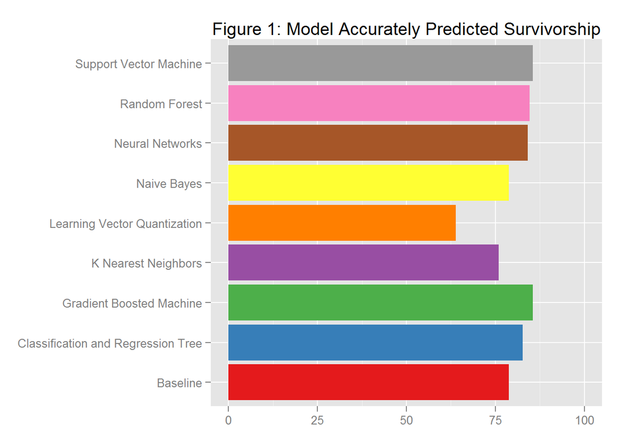

When looking at the more concervative kappa measure, the same five of the machine learning algorythms outpreformed the baseline model.

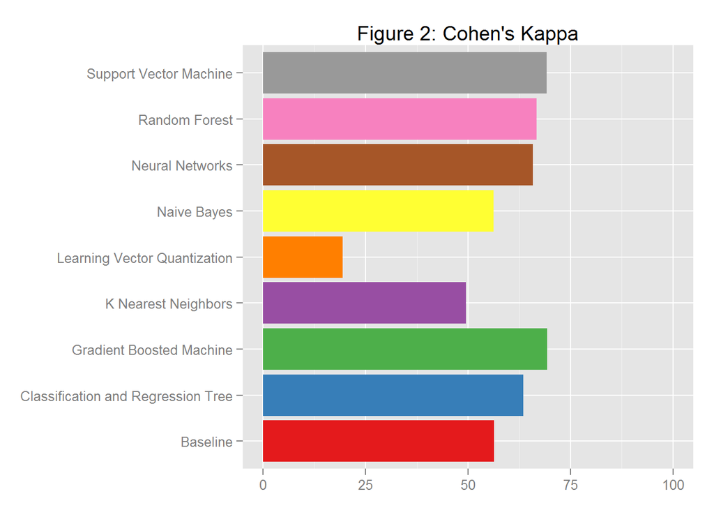

The is considerable difference in the amount of time needed to generate the models. Remember we assumed that it took one minute to program the baseline model.

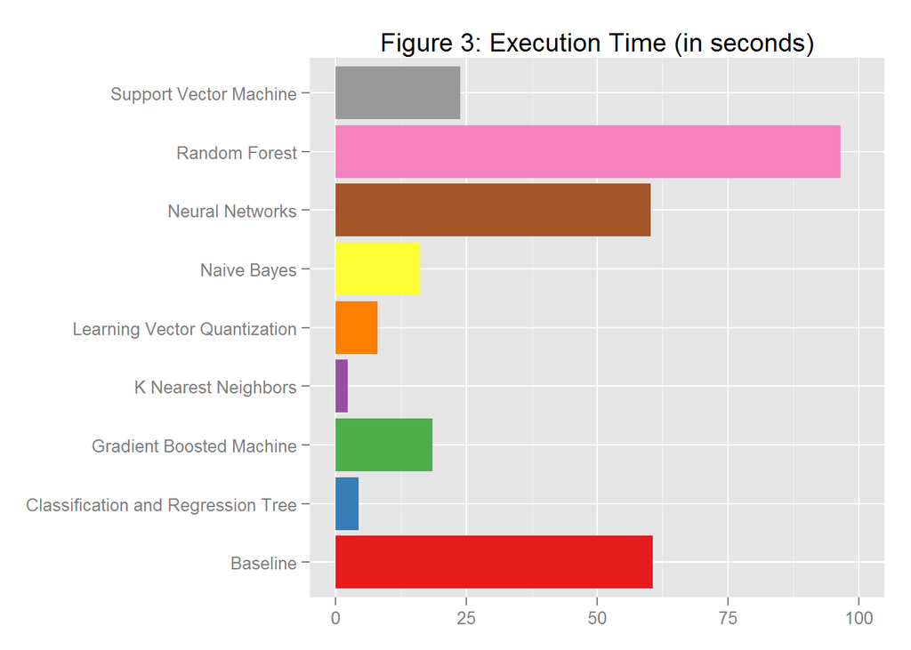

Now that we have a data set we can compare on I will be creating some index numbers. The first will be an accuracy index which is an equal weighting of both accuracy measures. The second will be a speed index which is based on the execution time. Each index is computed relative to the baseline and scaled so the baseline equals 100.

```r
compare <- compare %>%
  mutate(accuracy.index = ((accuracy + kappa)/2)) %>%
  mutate(speed.index = elapsed)

baseline.accuracy <- compare[compare$model.name=='Baseline',]$accuracy.index

baseline.speed <- compare[compare$model.name=='Baseline',]$speed.index

compare <- compare %>%
  mutate(accuracy.index = (accuracy.index/baseline.accuracy)*100) %>%
  mutate(speed.index = (compare$speed.index/baseline.speed)*100)
```

Now we can examine the model’s preformance in terms of speed and accuracy:

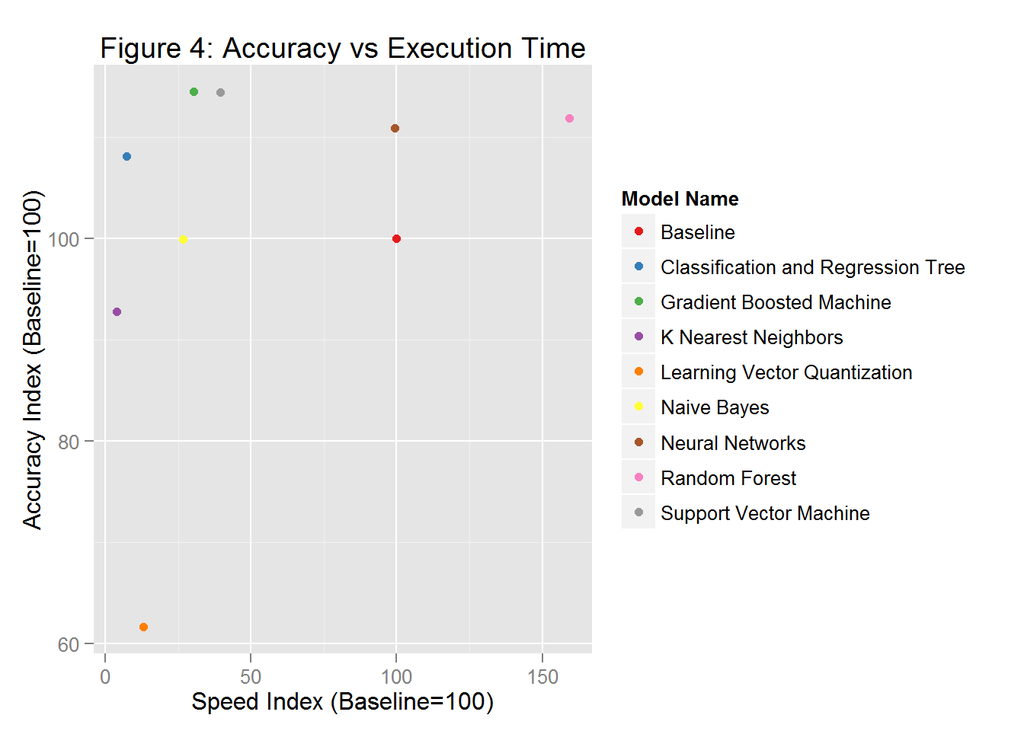

# Appendix

## Titanic Survivor Dataset

|  | pclass | survived | name | sex | age | sibsp | parch | ticket | fare | cabin | embarked | boat | body | home.dest |
| --- | --- | --- | --- | --- | --- | --- | --- | --- | --- | --- | --- | --- | --- | --- |
| 1 | 1 | Yes | Allen, Miss. Elisabeth Walton | female | 29 | 0 | 0 | 24160 | 211.3375 | B5 | S | 2 |  | St Louis, MO |
| 2 | 1 | Yes | Allison, Master. Hudson Trevor | male | 0.9167 | 1 | 2 | 113781 | 151.55 | C22 C26 | S | 11 |  | Montreal, PQ / Chesterville, ON |
| 3 | 1 | No | Allison, Miss. Helen Loraine | female | 2 | 1 | 2 | 113781 | 151.55 | C22 C26 | S |  |  | Montreal, PQ / Chesterville, ON |
| 4 | 1 | No | Allison, Mr. Hudson Joshua Creighton | male | 30 | 1 | 2 | 113781 | 151.55 | C22 C26 | S |  | 135 | Montreal, PQ / Chesterville, ON |
| 5 | 1 | No | Allison, Mrs. Hudson J C (Bessie Waldo Daniels) | female | 25 | 1 | 2 | 113781 | 151.55 | C22 C26 | S |  |  | Montreal, PQ / Chesterville, ON |
| 6 | 1 | Yes | Anderson, Mr. Harry | male | 48 | 0 | 0 | 19952 | 26.55 | E12 | S | 3 |  | New York, NY |
| 7 | 1 | Yes | Andrews, Miss. Kornelia Theodosia | female | 63 | 1 | 0 | 13502 | 77.9583 | D7 | S | 10 |  | Hudson, NY |
| 8 | 1 | No | Andrews, Mr. Thomas Jr | male | 39 | 0 | 0 | 112050 | 0 | A36 | S |  |  | Belfast, NI |
| 9 | 1 | Yes | Appleton, Mrs. Edward Dale (Charlotte Lamson) | female | 53 | 2 | 0 | 11769 | 51.4792 | C101 | S | D |  | Bayside, Queens, NY |
| 10 | 1 | No | Artagaveytia, Mr. Ramon | male | 71 | 0 | 0 | PC 17609 | 49.5042 |  | C |  | 22 | Montevideo, Uruguay |

[output cut: 1299 more lines]

## Machine Learning Models

```r
gbm.model
```

```
## Stochastic Gradient Boosting
##
## 1043 samples
##    7 predictor
##    2 classes: 'No', 'Yes'
##
## No pre-processing
## Resampling: Cross-Validated (10 fold, repeated 3 times)
##
## Summary of sample sizes: 939, 939, 938, 939, 939, 940, ...
##
## Resampling results across tuning parameters:
##
##   interaction.depth  n.trees  Accuracy   Kappa      Accuracy SD
##   1                   50      0.7833380  0.5447692  0.03930174
##   1                  100      0.7944950  0.5701969  0.04169178
##   1                  150      0.7944888  0.5707621  0.04239710
##   2                   50      0.8054451  0.5842010  0.04368074
##   2                  100      0.8124626  0.6008757  0.04310699
##   2                  150      0.8121576  0.6016311  0.04258210
##   3                   50      0.8096026  0.5932102  0.04374045
##   3                  100      0.8130944  0.6029493  0.03897721
##   3                  150      0.8115257  0.6005060  0.04206183
##   Kappa SD
##   0.08419669
##   0.08664442
##   0.08732732
##   0.09440741
##   0.09405925
##   0.09168733
##   0.09471941
##   0.08410463
##   0.09028984
##
## Tuning parameter 'shrinkage' was held constant at a value of 0.1
## Accuracy was used to select the optimal model using  the largest value.
## The final values used for the model were n.trees = 100,
##  interaction.depth = 3 and shrinkage = 0.1.
```

```r
knn.model
```

```
## k-Nearest Neighbors
##
## 1043 samples
##    7 predictor
##    2 classes: 'No', 'Yes'
##
## No pre-processing
## Resampling: Cross-Validated (10 fold, repeated 3 times)
##
## Summary of sample sizes: 939, 939, 938, 939, 939, 940, ...
##
## Resampling results across tuning parameters:
##
##   k  Accuracy   Kappa      Accuracy SD  Kappa SD
##   5  0.6669448  0.2949177  0.04440613   0.09275633
##   7  0.6634283  0.2846980  0.04320524   0.09193912
##   9  0.6647134  0.2869692  0.04040741   0.08722506
##
## Accuracy was used to select the optimal model using  the largest value.
## The final value used for the model was k = 5.
```

```r
lvq.model
```

```
## Learning Vector Quantization
##
## 1043 samples
##    7 predictor
##    2 classes: 'No', 'Yes'
##
## No pre-processing
## Resampling: Cross-Validated (10 fold, repeated 3 times)
##
## Summary of sample sizes: 939, 939, 938, 939, 939, 940, ...
##
## Resampling results across tuning parameters:
##
##   size  k  Accuracy   Kappa      Accuracy SD  Kappa SD
##   4     1  0.6129268  0.1752680  0.07084359   0.11772501
##   6     1  0.6280128  0.2007493  0.07023084   0.13604420
##   6     6  0.6356356  0.1990819  0.04749380   0.10251321
##   8     1  0.6490476  0.2487495  0.03824130   0.09419905
##   8     6  0.6547840  0.2488968  0.04300165   0.09830481
##
## Accuracy was used to select the optimal model using  the largest value.
## The final values used for the model were size = 8 and k = 6.
```

```r
nb.model
```

```
## Naive Bayes
##
## 1043 samples
##    7 predictor
##    2 classes: 'No', 'Yes'
##
## No pre-processing
## Resampling: Cross-Validated (10 fold, repeated 3 times)
##
## Summary of sample sizes: 939, 939, 938, 939, 939, 940, ...
##
## Resampling results across tuning parameters:
##
##   usekernel  Accuracy   Kappa      Accuracy SD  Kappa SD
##   FALSE      0.7743633  0.5327682  0.03473664   0.07305083
##    TRUE      0.7574088  0.4768963  0.03115678   0.06734648
##
## Tuning parameter 'fL' was held constant at a value of 0
## Accuracy was used to select the optimal model using  the largest value.
## The final values used for the model were fL = 0 and usekernel = FALSE.
```

```r
nnet.model
```

```
## Neural Network
##
## 1043 samples
##    7 predictor
##    2 classes: 'No', 'Yes'
##
## No pre-processing
## Resampling: Cross-Validated (10 fold, repeated 3 times)
##
## Summary of sample sizes: 939, 939, 938, 939, 939, 940, ...
##
## Resampling results across tuning parameters:
##
##   size  decay  Accuracy   Kappa      Accuracy SD  Kappa SD
##   1     0e+00  0.7182116  0.3530287  0.10564602   0.28704361
##   1     1e-04  0.7223464  0.3579270  0.10504670   0.28501162
##   1     1e-01  0.7970834  0.5651723  0.03252824   0.07108777
##   3     0e+00  0.8015647  0.5739516  0.03479601   0.07588805
##   3     1e-04  0.7950923  0.5613147  0.04880089   0.10607188
##   3     1e-01  0.8076424  0.5874725  0.03990159   0.08799603
##   5     0e+00  0.8003133  0.5737561  0.03594188   0.07573550
##   5     1e-04  0.7964824  0.5651199  0.04319232   0.09301204
##   5     1e-01  0.8047885  0.5830718  0.03724036   0.07964133
##
## Accuracy was used to select the optimal model using  the largest value.
## The final values used for the model were size = 3 and decay = 0.1.
```

```r
rf.model
```

```
## Random Forest
##
## 835 samples
##   7 predictor
##   2 classes: 'No', 'Yes'
##
## No pre-processing
## Resampling: Cross-Validated (10 fold, repeated 3 times)
##
## Summary of sample sizes: 752, 752, 751, 752, 752, 752, ...
##
## Resampling results across tuning parameters:
##
##   mtry  Accuracy   Kappa      Accuracy SD  Kappa SD
##   2     0.7928428  0.5515118  0.04539346   0.10349071
##   5     0.7820759  0.5378130  0.04245491   0.09206266
##   8     0.7796376  0.5368102  0.04512580   0.09657816
##
## Accuracy was used to select the optimal model using  the largest value.
## The final value used for the model was mtry = 2.
```

```r
rpart.model
```

```
## CART
##
## 1043 samples
##    7 predictor
##    2 classes: 'No', 'Yes'
##
## No pre-processing
## Resampling: Cross-Validated (10 fold, repeated 3 times)
##
## Summary of sample sizes: 939, 939, 938, 939, 939, 940, ...
##
## Resampling results across tuning parameters:
##
##   cp          Accuracy   Kappa      Accuracy SD  Kappa SD
##   0.02000000  0.7894401  0.5474931  0.04341326   0.09488418
##   0.02470588  0.7785698  0.5285377  0.04504748   0.10280897
##   0.45647059  0.6570749  0.1976971  0.07775903   0.23369188
##
## Accuracy was used to select the optimal model using  the largest value.
## The final value used for the model was cp = 0.02.
```

```r
svm.model
```

```
## Support Vector Machines with Radial Basis Function Kernel
##
## 1043 samples
##    7 predictor
##    2 classes: 'No', 'Yes'
##
## No pre-processing
## Resampling: Cross-Validated (10 fold, repeated 3 times)
##
## Summary of sample sizes: 939, 939, 938, 939, 939, 940, ...
##
## Resampling results across tuning parameters:
##
##   C     Accuracy   Kappa      Accuracy SD  Kappa SD
##   0.25  0.8028471  0.5811036  0.04158431   0.08994847
##   0.50  0.8073314  0.5903148  0.04073282   0.08683215
##   1.00  0.8019223  0.5765986  0.03852774   0.08288524
##
## Tuning parameter 'sigma' was held constant at a value of 0.1848615
## Accuracy was used to select the optimal model using  the largest value.
## The final values used for the model were sigma = 0.1848615 and C = 0.5.
```

## Comparison Values

|  | model.name | accuracy | kappa | user.self | sys.self | elapsed | accuracy.index | speed.index |
| --- | --- | --- | --- | --- | --- | --- | --- | --- |
| 1 | Baseline | 0.7884615384615384 | 0.5638997426856 | 60.60000000000004 | 0 | 60.60000000000004 | 100 | 100 |
| 2 | Gradient Boosted Machine | 0.8557692307692307 | 0.6926411191015662 | 18.18000000000001 | 0.1099999999999994 | 18.44 | 114.4967969326481 | 30.42904290429041 |
| 3 | K Nearest Neighbors | 0.7596153846153846 | 0.495292633213627 | 2.210000000000008 | 0.04000000000000004 | 2.289999999999992 | 92.7938440210694 | 3.778877887788763 |
| 4 | Learning Vector Quantization | 0.6394230769230769 | 0.1938817693261677 | 7.810000000000002 | 0.07000000000000028 | 7.930000000000007 | 61.61850815060269 | 13.08580858085809 |
| 5 | Naive Bayes | 0.7884615384615384 | 0.5623146819703491 | 15.97 | 0.08999999999999986 | 16.12 | 99.88279310141841 | 26.60066006600659 |
| 6 | Neural Networks | 0.8413461538461539 | 0.6587112171837709 | 59.66999999999999 | 0.04000000000000004 | 60.22999999999999 | 110.9213486027568 | 99.38943894389432 |
| 7 | Random Forest | 0.8461538461538461 | 0.6671667166716672 | 92.49000000000001 | 3.260000000000001 | 96.55 | 111.9020918390862 | 159.3234323432342 |
| 8 | Classification and Regression Tree | 0.8269230769230769 | 0.6352654651729176 | 4.360000000000014 | 0 | 4.379999999999995 | 108.1211479861133 | 7.227722772277216 |
| 9 | Support Vector Machine | 0.8557692307692307 | 0.6914862058736279 | 22.85000000000001 | 0.8300000000000001 | 23.86000000000001 | 114.4113971771213 | 39.37293729372937 |